# Coursework Report

*N* removed NAs: 2

*N* removed typo: 1

*N* removed <18: 33

*N* total clean: 114

| Group | *N* | *M*<sub>age</sub> | *M*<sub>rating</sub> |
| --- | --- | --- | --- |
| Control | 51 | 20.96 | 5.50 |
| Experim | 63 | 21.44 | 7.13 |

**Main analysis results**

*t*(112) = -11.06, *p* < .001

[interactive chart not shown]

[figure not shown]

[interactive chart not shown]

# Coursework Report

Analysing Data, Spring 2020

# Methods

## Participants

| mean | sd | min | max |
| --- | --- | --- | --- |
| 21.23 | 2.56 | 18 | 30 |

## Design

The research question and conceptual hypothesis is ‘Does Colour Influence Attractiveness?’. Attractiveness as a continuous variable is a rating which was measured on a 9-point scale - a low score means that the man was percieved as less attractive, and a high score means that the man was percieved as more attractive. The ratings were taken from three different research questions: ‘How attractive do you think this person is?’, ‘How pleasant is this person to look at?’, and ‘If I were to meet the person in this picture face to face, I would think he is attractive’. The ratings were all averaged to form a compositite score. Additionally, the colour of the frame behind the man is an independent categorical variable with two levels (white as the control, and red as the experimental). The operational hypothesis is ‘does viewing a different colour frame surrounding an image of a moderately attractive man influence the mean ratings of his attractiveness?’ The statistical analysis that will be conducted to test this will be t-test to compare the difference in means.

# Results

This study investigated whether participants would give different ratings of a male’s perceived attractiveness depending on colour condition (red and white), using an independent-measures *t*-test. The analysis indicated that, as predicted, men with a red background were given higher mean attractiveness ratings (*M* = 7.13) in comparison to the white background (*M* = 5.5). This difference in means was significant (*M*<sub>diff</sub> = 1.63, 95% CI [-1.92, -1.34], *t* (112) = -11.06, *p* = .0000000).

*Table 2* Summary of Mean ratings by Experimental Condition

| Condition | Question 1 *Mean* | Question 1 *SD* | Question 2 *Mean* | Question 2 *SD* | Question 3 *Mean* | Question 3 *SD* |
| --- | --- | --- | --- | --- | --- | --- |
| control | 5.49 | 1.49 | 5.86 | 1.43 | 5.14 | 1.44 |
| experimental | 7.37 | 1.39 | 6.98 | 1.22 | 7.03 | 1.31 |

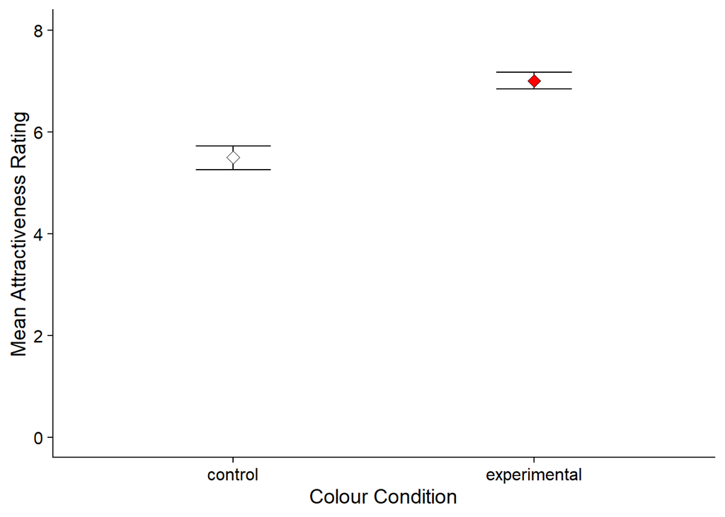

# Discussion

The results show that the male with the red background had a higher attractiveness rating than the male with the white background in the control condition. Therefore, we may conclude that colour influences ratings of attractiveness, as the control condition (white or no colour) results in lower attractiveness ratings.

In the original study, Elliot et al (2010) found that participants in the red condition perceived the male as more attractive, in comparison to those in the white condition. This is because the colour red is an indication of male status in many non-human species. Moreover, females have a mating preference for males with higher status (Elliot et al., 2010). My results showed a significant difference between the two conditions, in the same way as the original study. Similarly, in a more recent study, participants in both of the colour experimental conditions were provided ratings of perceived attractiveness with a small difference found between the average given ratings (Hesslinger et al., 2015).

In similar fashion to Francis (2013),there is a possibilty that this replication of Elliot’s analysis may have publication bias, as the probability that the findings would reject the null hypothesis is low. In addition, the design may lack ecological validity as the primary focus is colour impact, thus other essential factors such as typically attractive facial features are not acknowledged. Moreover, results may be limited, as the experiment uses only one photograph of a moderately attractive man throughout. The reason being that the experiment only measures the effect of colour on a reference point of medium attractiveness and it is unclear if the outcome will occur in regular interactions.

The results and analysis in this study support the hypothesis that people are percieved as more attractive with the colour red. However, further research should also be conducted, for example, testing the influence of red as seen on clothing, or make-up. Moreover, the amount of red on an individual and the relationship with attractiveness. For example, would a man wearing 3 items of clothing be viewed as more attractive in comparison to a man wearing just one red item? Alternative research could look into the influence of different colours on attractiveness - researchers have studied colours such as black and the impact on attractiveness (Peperkoorn et al., 2016).The connetations that a colour has may influence percieved attractiveness, as well as the mood that each colour invokes (red is an intense and emotional colour). It is also important to study different cultural differences as different ethnicities may have different beauty standards which would influence results. Lastly, additional research may be beneficial in other parts of society, such as to help people with dating lives and their choice of clothing, or to boost the moods of others with specific colours in interior decorating. In conclusion, it appears that the colour red influences percieved attractiveness in comparison to the colour white.

# References

Elliot, A. J., & Maier, M. A. (2013). The red-attractiveness effect, applying the Ioannidis and Trikalinos test, and the broader scientific context: A reply to Francis.

Elliot, A. J., Niesta Kayser, D., Greitemeyer, T., Lichtenfeld, S., Gramzow, R. H., Maier, M. A., & Liu, H. (2010). Red, rank, and romance in women viewing men. Journal of Experimental Psychology: General, 139(3), 399.

Francis, G. (2013). Publication bias in “Red, rank, and romance in women viewing men,” by Elliot et al.(2010).

Hesslinger, V. M., Goldbach, L., & Carbon, C. C. (2015). Men in red: A reexamination of the red-attractiveness effect. Psychonomic bulletin & review, 22(4), 1142-1148.

Peperkoorn, L. S., Roberts, S. C., & Pollet, T. V. (2016). Revisiting the red effect on attractiveness and sexual receptivity: No effect of the color red on human mate preferences. Evolutionary Psychology, 14(4), 1474704916673841.